# 質量占一半的成分,*訊號可能只剩 5%*

## 把被遮蔽的次成分挖出來

如果知道主成分是什麼,就能把它扣掉:用最小平方縮放主成分參考、相減,殘差裡次成分的峰會重新現身。這是「已知參考」的解混;若參考未知,則用盲解混(NMF / MCR-ALS)。

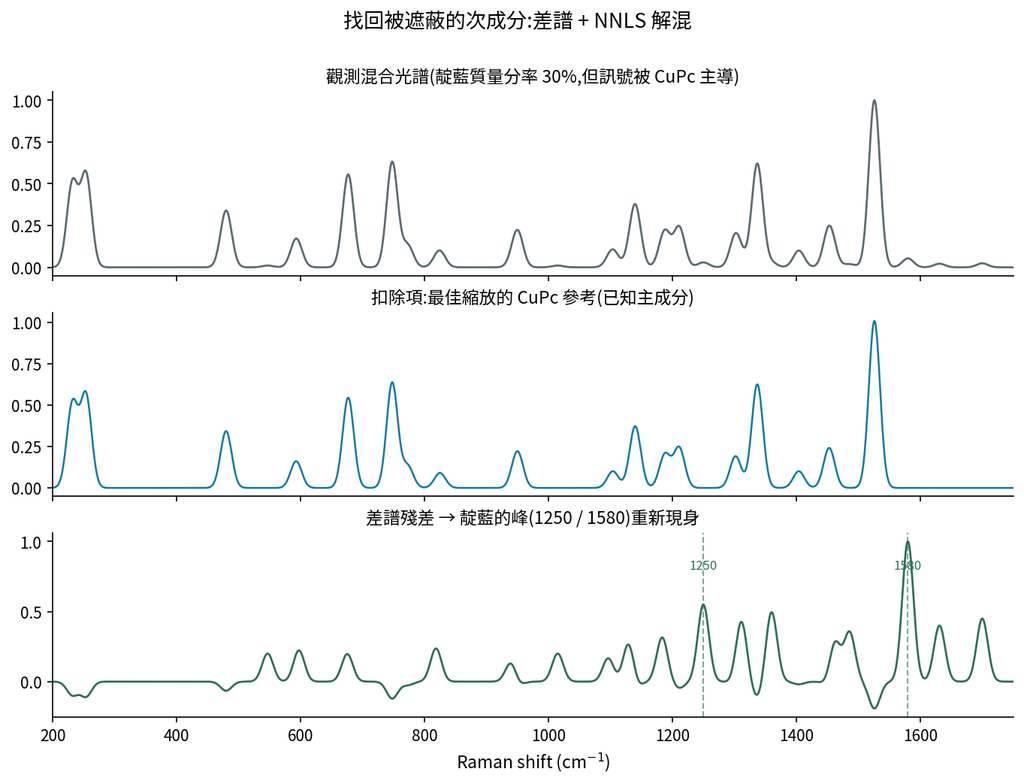

**上:**觀測混合(靛藍 30% 質量,訊號被 CuPc 主導)· **中:**扣除縮放後的 CuPc 參考 · **下:**殘差顯露靛藍的 1250 / 1580 峰。NNLS 估得靛藍訊號分率約 5%。

05 處理策略

## 混合物判讀的工具箱

差譜

### 扣除已知主成分

最小平方縮放主成分參考後相減,殘差顯露次成分。最簡單、最直覺,前提是知道主成分。

CLS / NNLS

### 已知參考的解混

用參考庫解非負最小平方,估各成分的訊號貢獻。`scipy.optimize.nnls`。得到的是訊號分率,要換質量需散射強度校正。

MCR-ALS / NMF

### 盲解混(參考未知)

只有一批混合光譜、不知純成分時,用非負矩陣分解同時解出「純光譜」與「濃度」。

2nd deriv

### 二階微分

放大被主峰肩部藏住的弱峰、壓低寬背景。Savitzky–Golay 微分即可。

換波長 / SERS

### 改變相對增強

共振增強看雷射波長:換激發波長或用 SERS,可以改變誰被增強,讓原本被蓋住的成分跳出來。

PLS 迴歸

### 定量而非只是判定

有一系列已知比例的混合(見 mixture library),可建 PLS 模型直接由光譜預測含量——接你既有的 PLS 教學。

06 三工具

## 解混怎麼做

```
# 差譜:扣除縮放後的主成分
scale = mix @ cupc / (cupc @ cupc)
residual = mix - scale * cupc          # 殘差裡看次成分

# NNLS 解混(已知參考庫)
from scipy.optimize import nnls
R = np.column_stack([cupc, indigo])    # 參考當欄
abund, _ = nnls(R, mix)                # 非負訊號貢獻
sig_frac = abund[1] / abund.sum()    # 訊號分率(≠質量)

# 盲解混(參考未知)
from sklearn.decomposition import NMF
W = NMF(n_components=2, init='nndsvda').fit(X)   # X = 一批混合光譜

# 定量:PLS 由光譜預測含量
from sklearn.cross_decomposition import PLSRegression
PLSRegression(5).fit(X, indigo_mass_fraction)
```

**資料誠實性:**光譜由峰位表合成。CuPc 峰位取自文獻並以實測樣品錨定;靛藍取自 indigo/indigotin 與 indigo carmine 的 Raman/SERRS 文獻(強峰 ~1580);FCF 取自 Erioglaucine SERS 文獻。**散射強度比 k 為教學參數**——真實相對截面依分子與雷射波長之共振而定,不是固定值。  
**真實案例:**文獻中商業食用色素(靛藍 + 葡萄糖)裡,靛藍因含量低,只能用 micro-Raman 偵測到——正是「散射/濃度落差」在真實樣品的體現。課堂可換上學生自己配的已知比例混合,流程完全相同。